# What they have learned? Part 2

Aleksandra Grudziąż, Anna Kozak

First created on May 29, 2018. Updated on Nov 09, 2020

In the vignette below we will see how a four selected models that predict the price of flats find relationships between dependent variables and variables from the model.

```r
library(DALEX)
library(caret)
library(xgboost)
library(e1071)
```

# 1 Data set and model

To illustrate applications of *DALEX* to find differences between variables we will use an artificial dataset `apartments` available in the DALEX package. Our goal is to predict the price per square meter of an apartment based on selected features such as construction year, surface, floor, number of rooms, district. It should be noted that four of these variables are continuous while the fifth one is a categorical one. Prices are given in Euro.

```r
head(apartments)
```

```
##   m2.price construction.year surface floor no.rooms    district
## 1     5897              1953      25     3        1 Srodmiescie
## 2     1818              1992     143     9        5     Bielany
## 3     3643              1937      56     1        2       Praga
## 4     3517              1995      93     7        3      Ochota
## 5     3013              1992     144     6        5     Mokotow
## 6     5795              1926      61     6        2 Srodmiescie
```

## 1.1 True relation in data

Our simulated response variable `m2.price` is the function of 5 features:

$$5000 + 600*(|construction.year-1965|>30) - 10*surface - 100*floor - 50*no.rooms + 1.5*district$$
where instead of variable `construction.year` we have the logical variable telling us whether the flat was built before 1934 or after 1996 (then it has value 1) or between 1935 and 1995 (then it has value 0).

# 2 Creating models

We will consider four models: random forest, support vector machine, linear regression and gradient boosting model.

```r
set.seed(123)
regr_rf <- train(m2.price~., data = apartments, method="rf", ntree = 100)
regr_svm <- train(m2.price~., data = apartments, method="svmLinear")
regr_svm_e1071 <- svm(m2.price~., data=apartments)
regr_lm <- lm(m2.price~., data=apartments)

model_matrix_train <- model.matrix(m2.price ~ . - 1, apartments)
data_train <- xgb.DMatrix(model_matrix_train, label = apartments$m2.price)
regr_xgb <- xgb.train(data = data_train, nrounds = 50)
```

# 3 Explainers

To create an explainer for these models it is enough to use `explain()` function with the model, data and y parameters. Validation dataset for the models is `apartmentsTest` data from the *DALEX* package.

```r
explainer_rf <- explain(regr_rf, data = apartmentsTest[,2:6], y = apartmentsTest$m2.price, label="rf")
explainer_svm <- explain(regr_svm, data = apartmentsTest[,2:6], y = apartmentsTest$m2.price, label="svm")
explainer_svm_e1071 <- explain(regr_svm_e1071, data = apartmentsTest[,2:6], y = apartmentsTest$m2.price, label="svm_e1071")
explainer_lm <- explain(regr_lm, data = apartmentsTest[,2:6], y = apartmentsTest$m2.price, label="lm")

model_matrix_test <- model.matrix(m2.price~.-1, apartmentsTest)
explainer_xgb <- explain(regr_xgb, data = model_matrix_test, y = apartmentsTest$m2.price, label = "xgboost")

true_relation <- function(x1,x2,x3,x4,x5){
  levels(x5) <- c(-400, -400, 200, 200, -400, 1000, -400, -400, -400, 200)
  x5 <- as.numeric(as.character(x5))
  5000 +  600 * (abs(x1 - 1965) > 30)-10 * x2-100 * x3 -50 * x4+ 1.5 * x5
}

explainer_tr <- explain(NULL, data = apartmentsTest[,2:6], y = apartmentsTest$m2.price,
                 predict_function = function(m, x) true_relation(x[,1], x[,2], x[,3], x[,4], x[,5]),
                 label = "True Model")
```

# 4 Variable importance

Firstly, we use the `model_parts()` function to find out which variables are important in each model.

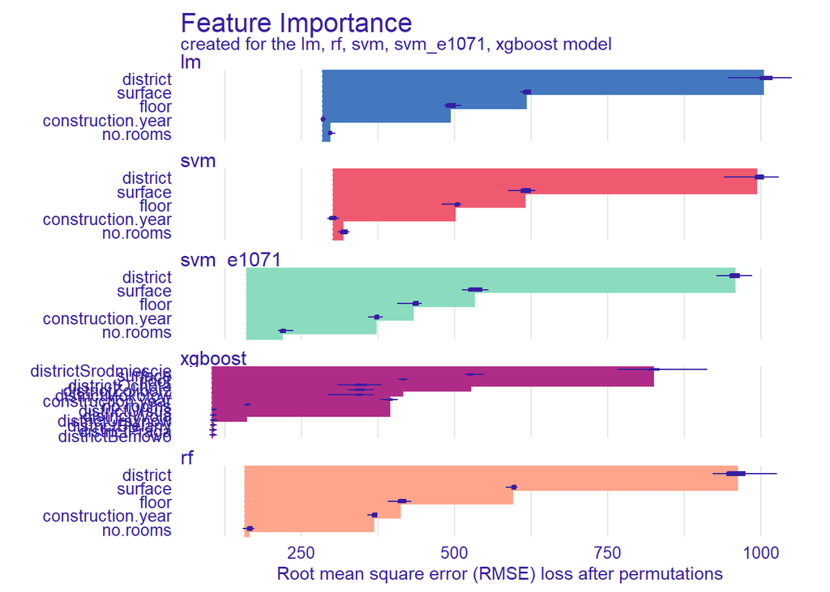

```r
vi_rf <- model_parts(explainer_rf)
vi_svm <- model_parts(explainer_svm)
vi_svm_e1071 <- model_parts(explainer_svm_e1071)
vi_lm <- model_parts(explainer_lm)
vi_xgb <- model_parts(explainer_xgb)

plot(vi_lm, vi_svm, vi_svm_e1071, vi_xgb, vi_rf)
```

In the plot above we see that the variables `surface`, `floor` and `district` are important in all considered models (in xgboost model we have to divide qualitative variable `district` into ten binary variables corresponding to each district in our previous data frame). In linear model and a svm model created by `caret` package we see that the `construction.year` isn’t an important variable.

# 5 Variables

Now we can focus on each variable and consider their impact on the `m2.price`. We we will see how a change in the value of a given variable affects the response of each model. for the analysis of the quantitative variables we will use the `model_profile()`function with the `partial` type.

## 5.1 Construction year

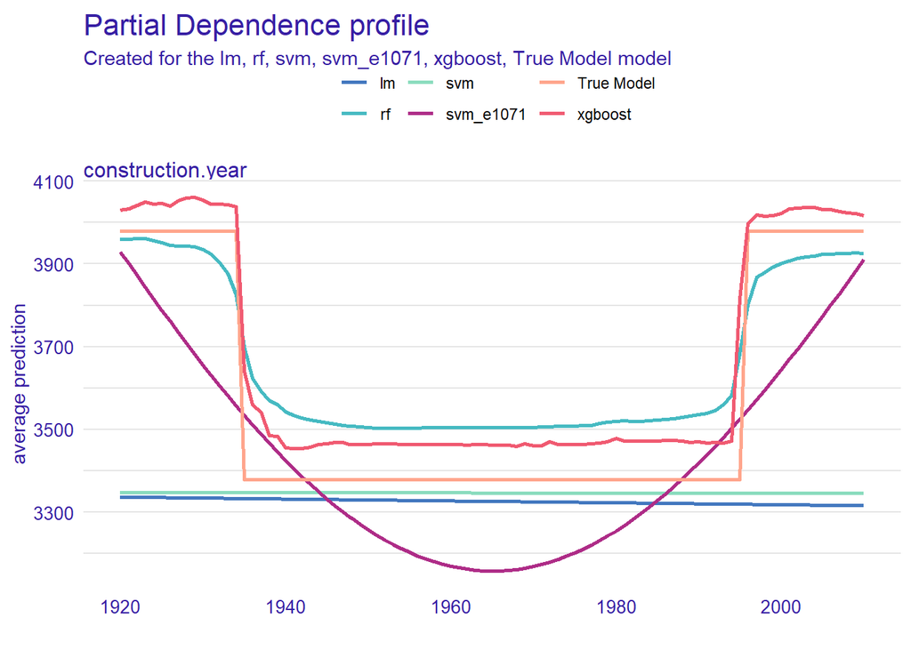

```r
sv_rf  <- model_profile(explainer_rf, variable =  "construction.year", type = "partial")
sv_lm  <- model_profile(explainer_lm, variable =  "construction.year", type = "partial")
sv_svm  <- model_profile(explainer_svm, variable =  "construction.year", type = "partial")
sv_svm_e1071  <- model_profile(explainer_svm_e1071, variable =  "construction.year", type = "partial")
sv_xgb  <- model_profile(explainer_xgb, variable =  "construction.year", type = "partial")
sv_tr <- model_profile(explainer_tr, variable =  "construction.year", type = "partial")

plot(sv_lm, sv_rf, sv_svm, sv_svm_e1071, sv_xgb, sv_tr)
```

For the variable `construction_year`, which was important in three of four models we see that the linear regression model and svm model didn’t capture the non-linear relationship between the considred variable and the mean `m2.price`. The xgboost model best guesses the real relationship in our data.

## 5.2 Surface

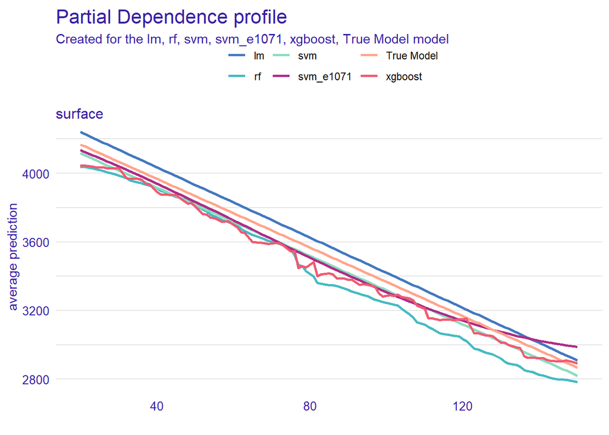

```r
sv_rf  <- model_profile(explainer_rf, variable =  "surface", type = "partial")
sv_lm  <- model_profile(explainer_lm, variable =  "surface", type = "partial")
sv_svm  <- model_profile(explainer_svm, variable =  "surface", type = "partial")
sv_xgb  <- model_profile(explainer_xgb, variable =  "surface", type = "partial")
sv_svm_e1071 <- model_profile(explainer_svm_e1071, variable =  "surface", type = "partial")
sv_tr <- model_profile(explainer_tr, variable =  "surface", type = "partial")

plot(sv_lm, sv_rf, sv_svm, sv_svm_e1071, sv_xgb, sv_tr)
```

For the variable `surface` we see that all of the models have nearly the same performance and for this variable we see that the apartments with larger surface have the smaller mean price per square meter, than flats with the smaller surface.

## 5.3 Floor

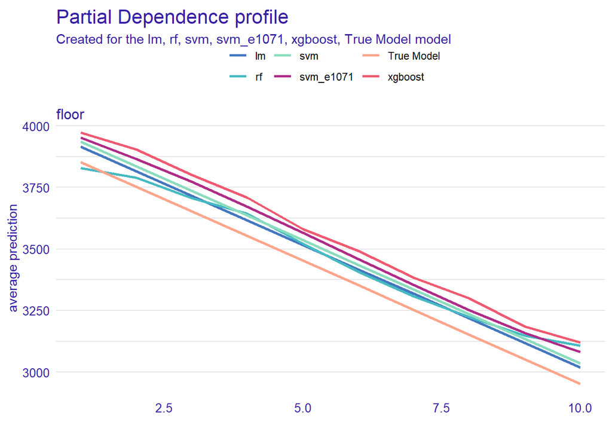

```r
sv_rf  <- model_profile(explainer_rf, variable =  "floor", type = "partial")
sv_lm  <- model_profile(explainer_lm, variable =  "floor", type = "partial")
sv_svm  <- model_profile(explainer_svm, variable =  "floor", type = "partial")
sv_xgb  <- model_profile(explainer_xgb, variable =  "floor", type = "partial")
sv_svm_e1071 <- model_profile(explainer_svm_e1071, variable =  "floor", type = "partial")
sv_tr <- model_profile(explainer_tr, variable =  "floor", type = "partial")

plot(sv_lm, sv_rf, sv_svm, sv_svm_e1071, sv_xgb, sv_tr)
```

## 5.4 District

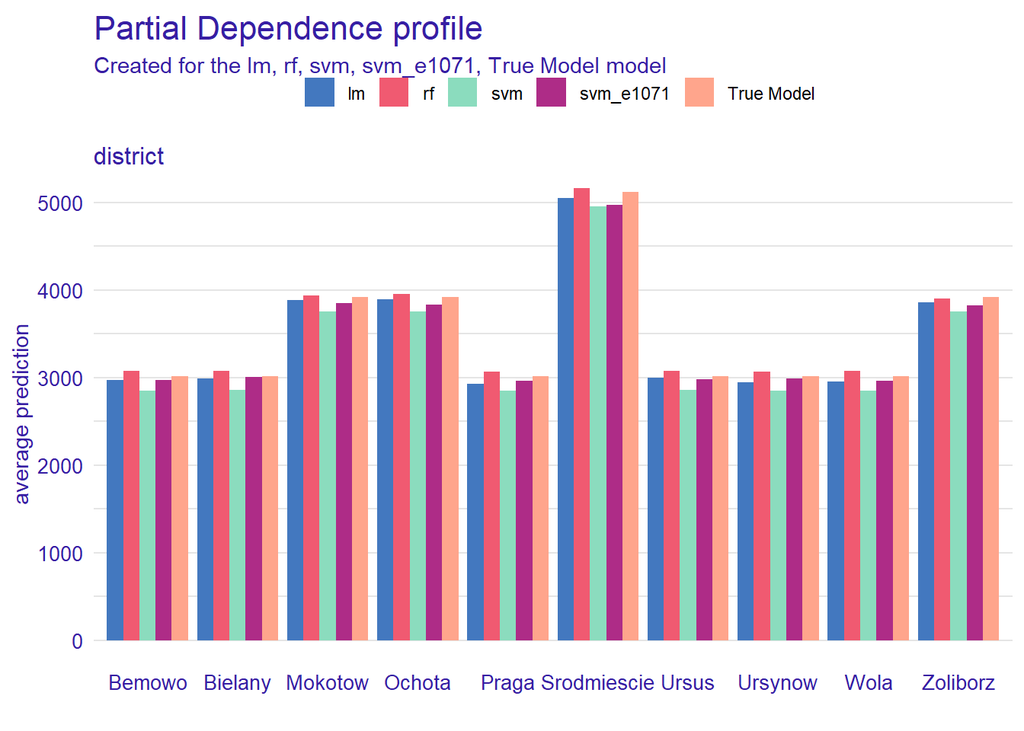

```r
sv_rf  <- model_profile(explainer_rf, variable =  "district", type = "partial")
sv_lm  <- model_profile(explainer_lm, variable =  "district", type = "partial")
sv_svm  <- model_profile(explainer_svm, variable =  "district", type = "partial")
sv_svm_e1071 <- model_profile(explainer_svm_e1071, variable =  "district", type = "partial")
sv_tr <- model_profile(explainer_tr, variable =  "district", type = "partial")


plot(sv_lm, sv_rf, sv_svm, sv_svm_e1071, sv_tr)
```

For the variable `district` we see that all of the models have nearly the same performance. We can see three clusters in the plots above: the city center (Srodmiescie), districts well communicated with city center (Ochota, Mokotow, Zoliborz) and other districts closer to city boundaries.